## Evaluación parcial

### Seminario de física computacional

### Julio Cesar Cons Calderón

# Phishing

[figure not shown]

*Phishing* es un término informático que distingue a un conjunto de técnicas que persiguen el engaño a una víctima ganándose su confianza haciéndose pasar por una persona, empresa o servicio de confianza (suplantación de identidad de tercero de confianza), para manipularla y hacer que realice acciones que no debería realizar (por ejemplo revelar información confidencial o hacer click en un enlace).

### Técnicas de phishing

-*Phishing general, phishing tradicional, Bulk Phishing o Spray and pray.* Consiste en la emisión masiva de correos electrónicos a usuarios. Estos correos suplantan a entidades de confianza (ejemplo bancos) y persiguen el engaño del usuario y la consecución de información. Por ejemplo en el mensaje se incluyen enlaces a dominios maliciosos. Para camuflar estos enlaces es habitual que el texto del enlace sea la URL correcta, pero el enlace en sí apunte al sitio malicioso.

-*Vishing.* Es similar al phishing tradicional pero el engaño se produce a través de una llamada telefónica. El término deriva de la unión de dos palabras en inglés: ‘'voice'’ y ‘'phishing’'. Un ejemplo típico de uso de esta técnica es cuando un ciberdelincuente ha robado ya información confidencial a través de un ataque de phising, pero necesita la clave SMS o token digital para realizar y validar una operación. Es en ese momento el ciberdelincuente llama por teléfono al cliente identificándose como personal del banco y, con mensajes particularmente alarmistas, intenta de que el cliente revele el número de su clave SMS o token digital, que son los necesarios para autorizar la transacción.

-*Smishing.* Es similar al phishing tradicional pero el engaño se produce a través mensajes de texto ya sean por SMS o mensajería instantánea (como WhatsApp). Un ejemplo típico de esta técnica es cuando el cliente recibe un mensaje de texto, donde el emisor se hace pasar por el banco, y le informan que se ha realizado una compra sospechosa con su tarjeta de crédito. A su vez, el texto solicita que se comunique con la banca por teléfono de la entidad financiera y le brinda un número falso. El cliente devuelve la llamada y es ahí cuando el ciberdelincuente, haciéndose pasar por el banco, solicita información confidencial para supuestamente cancelar la compra. En una variante de esta modalidad el mensaje también podría incluir un enlace a una ‘web’ fraudulenta para solicitar información sensible.12

## URL Phishing

En este proyecto trataremos de combatir el *URL Phishing*, a través de una red neuronal. En Kaggle, existe una base de datos que presenta una cantidad considerable de URL's, que esta descompuesta en varios factores. Descargamos esta base de datos, y la abrimos con la libreria pandas

```python
import pandas as pd
df = pd.read_csv("archive/phishing.csv")
df
```

|  | Index | UsingIP | LongURL | ShortURL | Symbol@ | Redirecting// | PrefixSuffix- | SubDomains | HTTPS | DomainRegLen | ... | UsingPopupWindow | IframeRedirection | AgeofDomain | DNSRecording | WebsiteTraffic | PageRank | GoogleIndex | LinksPointingToPage | StatsReport | class |
| --- | --- | --- | --- | --- | --- | --- | --- | --- | --- | --- | --- | --- | --- | --- | --- | --- | --- | --- | --- | --- | --- |
| 0 | 0 | 1 | 1 | 1 | 1 | 1 | -1 | 0 | 1 | -1 | ... | 1 | 1 | -1 | -1 | 0 | -1 | 1 | 1 | 1 | -1 |
| 1 | 1 | 1 | 0 | 1 | 1 | 1 | -1 | -1 | -1 | -1 | ... | 1 | 1 | 1 | -1 | 1 | -1 | 1 | 0 | -1 | -1 |
| 2 | 2 | 1 | 0 | 1 | 1 | 1 | -1 | -1 | -1 | 1 | ... | 1 | 1 | -1 | -1 | 1 | -1 | 1 | -1 | 1 | -1 |
| 3 | 3 | 1 | 0 | -1 | 1 | 1 | -1 | 1 | 1 | -1 | ... | -1 | 1 | -1 | -1 | 0 | -1 | 1 | 1 | 1 | 1 |
| 4 | 4 | -1 | 0 | -1 | 1 | -1 | -1 | 1 | 1 | -1 | ... | 1 | 1 | 1 | 1 | 1 | -1 | 1 | -1 | -1 | 1 |
| ... | ... | ... | ... | ... | ... | ... | ... | ... | ... | ... | ... | ... | ... | ... | ... | ... | ... | ... | ... | ... | ... |
| 11049 | 11049 | 1 | -1 | 1 | -1 | 1 | 1 | 1 | 1 | -1 | ... | -1 | -1 | 1 | 1 | -1 | -1 | 1 | 1 | 1 | 1 |
| 11050 | 11050 | -1 | 1 | 1 | -1 | -1 | -1 | 1 | -1 | -1 | ... | -1 | 1 | 1 | 1 | 1 | 1 | 1 | -1 | 1 | -1 |
| 11051 | 11051 | 1 | -1 | 1 | 1 | 1 | -1 | 1 | -1 | -1 | ... | 1 | 1 | 1 | 1 | 1 | -1 | 1 | 0 | 1 | -1 |
| 11052 | 11052 | -1 | -1 | 1 | 1 | 1 | -1 | -1 | -1 | 1 | ... | -1 | 1 | 1 | 1 | 1 | -1 | 1 | 1 | 1 | -1 |
| 11053 | 11053 | -1 | -1 | 1 | 1 | 1 | -1 | -1 | -1 | 1 | ... | 1 | 1 | -1 | 1 | -1 | -1 | -1 | 1 | -1 | -1 |

11054 rows × 32 columns

Haremos un proceso de limpieza de la base de datos. Eliminaremos una fila o una columna que tenga mas del 30% de valores inválidos.

```python
por_filas = int(len(df)*0.3)
por_columnas = int(len(df.columns)*0.3)

print("Numero de entradas invalidas para eliminar filas: ",por_filas)
print("Numero de entradas invalidas para eliminar columnas: ",por_columnas)
```

```
Numero de entradas invalidas para eliminar filas:  3316
Numero de entradas invalidas para eliminar columnas:  9
```

```python
import math
del_filas=[]
num_columns=len(df.columns)
for i in range(len(df)):
    m=0
    for j in range(num_columns):
        try:
            boolean = math.isnan(df.iloc[i,j])
            if boolean:
                m+=1
        except:
            pass
    if m > por_filas:
        del_filas.append(i)
```

```python
del_columnas_nan=[]
num_columns=len(df.columns)
for i in range(num_columns):
    m=0
    for j in range(len(df)):
        try:
            boolean = math.isnan(df.iloc[j,i])
            if boolean:
                m+=1
        except:
            pass
    if m > por_columnas:
        del_columnas_nan.append(i)
```

Imprimimos que columnas y filas serán eliminados.

```python
print(del_columnas_nan)
print(del_filas)
```

```
[]
[]
```

Eliminamos las columnas y filas necesarias.

```python
del_columnas_nan = df.columns[del_columnas_nan].tolist()
```

```python
df = df.drop(del_filas,axis=0).reset_index(drop=True)
df = df.drop(del_columnas_nan, axis=1)
```

También para no sobrecargar las red neuronal, eliminaremos las columnas que tengan un indice de correlación mayor 0.9. Si dos columnas tienen una correlación alta, una de las dos son redundantes, por lo que podemos eliminar cualquiera de las dos.

Cargamos la matriz de correlación entre los datos.

```python
corr_matrix = df.corr()
corr_matrix
```

|  | Index | UsingIP | LongURL | ShortURL | Symbol@ | Redirecting// | PrefixSuffix- | SubDomains | HTTPS | DomainRegLen | ... | UsingPopupWindow | IframeRedirection | AgeofDomain | DNSRecording | WebsiteTraffic | PageRank | GoogleIndex | LinksPointingToPage | StatsReport | class |
| --- | --- | --- | --- | --- | --- | --- | --- | --- | --- | --- | --- | --- | --- | --- | --- | --- | --- | --- | --- | --- | --- |
| Index | 1.000000 | -0.388620 | 0.006441 | -0.006221 | -0.169437 | -0.003771 | -0.007402 | 0.233936 | -0.006899 | -0.001290 | ... | 0.006593 | 0.002583 | 0.115175 | 0.400751 | -0.015147 | 0.065034 | -0.012466 | 0.002623 | 0.163479 | 0.000802 |
| UsingIP | -0.388620 | 1.000000 | -0.052159 | 0.403547 | 0.158766 | 0.397220 | -0.005306 | -0.080921 | 0.071255 | -0.022830 | ... | 0.096953 | 0.054739 | -0.010580 | -0.050929 | 0.002728 | -0.091857 | 0.029206 | -0.338971 | -0.019420 | 0.094033 |
| LongURL | 0.006441 | -0.052159 | 1.000000 | -0.097976 | -0.075205 | -0.080788 | 0.055334 | 0.004249 | 0.049033 | -0.221807 | ... | -0.049486 | -0.013902 | 0.179678 | -0.040549 | 0.009296 | 0.183672 | 0.002825 | -0.023216 | -0.066708 | 0.057661 |
| ShortURL | -0.006221 | 0.403547 | -0.097976 | 1.000000 | 0.104433 | 0.843149 | -0.080458 | -0.041874 | -0.061383 | 0.060950 | ... | 0.036599 | 0.016570 | -0.052562 | 0.436163 | -0.047025 | 0.014612 | 0.155832 | -0.198463 | 0.085572 | -0.067931 |
| Symbol@ | -0.169437 | 0.158766 | -0.075205 | 0.104433 | 1.000000 | 0.087086 | -0.011711 | -0.058931 | 0.031275 | 0.015549 | ... | 0.290880 | 0.284401 | -0.005459 | -0.047820 | 0.032981 | -0.064714 | 0.037047 | -0.006124 | -0.080286 | 0.052994 |
| Redirecting// | -0.003771 | 0.397220 | -0.080788 | 0.843149 | 0.087086 | 1.000000 | -0.085709 | -0.043401 | -0.036536 | 0.047314 | ... | 0.054595 | 0.010536 | -0.050374 | 0.431235 | -0.062761 | -0.003272 | 0.178565 | -0.193965 | 0.069849 | -0.038885 |
| PrefixSuffix- | -0.007402 | -0.005306 | 0.055334 | -0.080458 | -0.011711 | -0.085709 | 1.000000 | 0.087852 | 0.261366 | -0.096826 | ... | -0.014716 | -0.036894 | 0.074083 | -0.016610 | 0.110555 | -0.006855 | 0.067796 | 0.067469 | -0.002851 | 0.348588 |
| SubDomains | 0.233936 | -0.080921 | 0.004249 | -0.041874 | -0.058931 | -0.043401 | 0.087852 | 1.000000 | 0.267531 | -0.082930 | ... | -0.025257 | 0.010675 | 0.119144 | 0.125340 | -0.005948 | 0.120672 | 0.057725 | -0.010392 | 0.081365 | 0.298231 |
| HTTPS | -0.006899 | 0.071255 | 0.049033 | -0.061383 | 0.031275 | -0.036536 | 0.261366 | 0.267531 | 1.000000 | -0.193730 | ... | -0.012945 | -0.002734 | 0.162700 | 0.050797 | 0.258625 | 0.074479 | 0.096110 | -0.011569 | 0.063126 | 0.714704 |
| DomainRegLen | -0.001290 | -0.022830 | -0.221807 | 0.060950 | 0.015549 | 0.047314 | -0.096826 | -0.082930 | -0.193730 | 1.000000 | ... | 0.051443 | 0.004414 | -0.062924 | -0.010573 | -0.134571 | -0.059938 | -0.039741 | 0.122755 | -0.002371 | -0.225879 |
| Favicon | 0.007369 | 0.087093 | -0.042599 | 0.006084 | 0.304887 | 0.035223 | -0.007487 | -0.016650 | -0.014699 | 0.054286 | ... | 0.939632 | 0.627603 | -0.002582 | 0.088285 | -0.050861 | 0.011725 | -0.016685 | -0.127302 | 0.301111 | -0.000231 |
| NonStdPort | 0.001718 | 0.061035 | 0.000247 | 0.002187 | 0.364881 | 0.025161 | -0.022532 | 0.004910 | 0.027525 | 0.022503 | ... | 0.748513 | 0.687041 | 0.008497 | 0.054908 | -0.028490 | 0.017975 | -0.005428 | -0.139155 | 0.344174 | 0.036461 |
| HTTPSDomainURL | 0.002561 | 0.363366 | -0.088984 | 0.758099 | 0.104672 | 0.760675 | -0.070250 | -0.037518 | -0.030233 | 0.059031 | ... | 0.067074 | 0.017578 | -0.049865 | 0.395213 | -0.040042 | 0.020988 | 0.115560 | -0.128525 | 0.095727 | -0.040096 |
| RequestURL | -0.000732 | 0.029880 | 0.246247 | -0.037265 | 0.027879 | -0.026182 | 0.098708 | 0.104965 | 0.193180 | -0.609950 | ... | -0.004659 | 0.016911 | 0.090543 | 0.016046 | 0.161305 | 0.055781 | 0.046380 | -0.067201 | 0.035608 | 0.253478 |
| AnchorURL | -0.005275 | 0.099701 | -0.023153 | 0.000607 | 0.057968 | -0.005341 | 0.348854 | 0.229374 | 0.535712 | -0.160355 | ... | 0.041211 | 0.013441 | 0.075393 | 0.093131 | 0.326172 | 0.099201 | 0.038866 | 0.018788 | 0.077115 | 0.692895 |
| LinksInScriptTags | -0.028643 | 0.006397 | 0.052603 | -0.133444 | -0.070924 | -0.125289 | 0.100316 | 0.093835 | 0.177039 | -0.101003 | ... | -0.112359 | -0.070079 | 0.078209 | -0.038355 | 0.064767 | -0.006373 | 0.045509 | 0.013411 | -0.087048 | 0.248415 |
| ServerFormHandler | 0.085283 | -0.011030 | 0.414389 | -0.022705 | -0.008652 | -0.041810 | 0.001307 | 0.096035 | 0.171353 | -0.136461 | ... | -0.004839 | 0.007082 | -0.015892 | 0.034372 | 0.052638 | 0.001950 | 0.027608 | -0.009013 | -0.005410 | 0.221380 |
| InfoEmail | 0.005498 | 0.077746 | -0.014055 | 0.049413 | 0.370281 | 0.031416 | -0.045085 | 0.008583 | 0.007801 | 0.039134 | ... | 0.629691 | 0.577671 | 0.007155 | 0.063880 | -0.015988 | 0.026101 | -0.008302 | -0.039746 | 0.351768 | 0.018039 |
| AbnormalURL | 0.002852 | 0.336365 | -0.106347 | 0.739573 | 0.204091 | 0.723569 | -0.077726 | -0.035203 | -0.046560 | 0.057972 | ... | 0.091320 | 0.017664 | -0.032774 | 0.366642 | -0.052774 | 0.007191 | 0.124872 | -0.160828 | 0.185960 | -0.060751 |
| WebsiteForwarding | 0.016750 | -0.321256 | 0.046912 | -0.534524 | -0.028146 | -0.591747 | 0.016259 | 0.031166 | -0.021117 | -0.016323 | ... | -0.026311 | -0.012657 | -0.022512 | -0.211167 | 0.004581 | 0.052848 | 0.057244 | 0.161326 | -0.059292 | -0.020151 |
| StatusBarCust | 0.003708 | 0.084113 | -0.045183 | 0.062371 | 0.279687 | 0.086748 | 0.012591 | -0.018040 | 0.023634 | 0.023808 | ... | 0.733625 | 0.659474 | 0.013342 | 0.087220 | -0.036484 | 0.015654 | -0.006523 | -0.038592 | 0.277508 | 0.041878 |
| DisableRightClick | -0.005232 | 0.042912 | -0.013657 | 0.038111 | 0.219497 | 0.025921 | -0.024861 | 0.018256 | 0.015882 | 0.023535 | ... | 0.415264 | 0.655861 | 0.006785 | 0.038287 | -0.013566 | 0.025353 | -0.008073 | -0.119861 | 0.204514 | 0.012675 |
| UsingPopupWindow | 0.006593 | 0.096953 | -0.049486 | 0.036599 | 0.290880 | 0.054595 | -0.014716 | -0.025257 | -0.012945 | 0.051443 | ... | 1.000000 | 0.629402 | -0.000901 | 0.098735 | -0.043126 | 0.017141 | -0.010274 | -0.121385 | 0.285453 | 0.000136 |
| IframeRedirection | 0.002583 | 0.054739 | -0.013902 | 0.016570 | 0.284401 | 0.010536 | -0.036894 | 0.010675 | -0.002734 | 0.004414 | ... | 0.629402 | 1.000000 | 0.018879 | 0.047341 | -0.022037 | 0.022425 | -0.003531 | -0.140866 | 0.268565 | -0.003362 |
| AgeofDomain | 0.115175 | -0.010580 | 0.179678 | -0.052562 | -0.005459 | -0.050374 | 0.074083 | 0.119144 | 0.162700 | -0.062924 | ... | -0.000901 | 0.018879 | 1.000000 | -0.034231 | 0.089814 | -0.147260 | -0.028434 | 0.040523 | 0.008880 | 0.121402 |
| DNSRecording | 0.400751 | -0.050929 | -0.040549 | 0.436163 | -0.047820 | 0.431235 | -0.016610 | 0.125340 | 0.050797 | -0.010573 | ... | 0.098735 | 0.047341 | -0.034231 | 1.000000 | 0.048450 | 0.137797 | 0.137578 | -0.318162 | 0.136578 | 0.075579 |
| WebsiteTraffic | -0.015147 | 0.002728 | 0.009296 | -0.047025 | 0.032981 | -0.062761 | 0.110555 | -0.005948 | 0.258625 | -0.134571 | ... | -0.043126 | -0.022037 | 0.089814 | 0.048450 | 1.000000 | 0.030905 | -0.012529 | -0.019701 | 0.008878 | 0.346003 |
| PageRank | 0.065034 | -0.091857 | 0.183672 | 0.014612 | -0.064714 | -0.003272 | -0.006855 | 0.120672 | 0.074479 | -0.059938 | ... | 0.017141 | 0.022425 | -0.147260 | 0.137797 | 0.030905 | 1.000000 | 0.032453 | -0.028156 | 0.030926 | 0.104593 |
| GoogleIndex | -0.012466 | 0.029206 | 0.002825 | 0.155832 | 0.037047 | 0.178565 | 0.067796 | 0.057725 | 0.096110 | -0.039741 | ... | -0.010274 | -0.003531 | -0.028434 | 0.137578 | -0.012529 | 0.032453 | 1.000000 | -0.038821 | -0.005014 | 0.129000 |
| LinksPointingToPage | 0.002623 | -0.338971 | -0.023216 | -0.198463 | -0.006124 | -0.193965 | 0.067469 | -0.010392 | -0.011569 | 0.122755 | ... | -0.121385 | -0.140866 | 0.040523 | -0.318162 | -0.019701 | -0.028156 | -0.038821 | 1.000000 | -0.016565 | 0.032694 |
| StatsReport | 0.163479 | -0.019420 | -0.066708 | 0.085572 | -0.080286 | 0.069849 | -0.002851 | 0.081365 | 0.063126 | -0.002371 | ... | 0.285453 | 0.268565 | 0.008880 | 0.136578 | 0.008878 | 0.030926 | -0.005014 | -0.016565 | 1.000000 | 0.079632 |
| class | 0.000802 | 0.094033 | 0.057661 | -0.067931 | 0.052994 | -0.038885 | 0.348588 | 0.298231 | 0.714704 | -0.225879 | ... | 0.000136 | -0.003362 | 0.121402 | 0.075579 | 0.346003 | 0.104593 | 0.129000 | 0.032694 | 0.079632 | 1.000000 |

32 rows × 32 columns

Recorremos cada una de las columnas y filas de la matriz de correlación, encontramos las que tenga una correlación absoluta arriba de 0.9, guardamos la correlación y las dos columnas que correlacionadas.

```python
del_columns=[]
for i in range(len(corr_matrix)):
    columns=[]
    for j in range(i):
        if i!=j:
            corr1=corr_matrix.iloc[i,j]
            if abs(corr1) > 0.9:
                del_columns.append((corr1,corr_matrix.columns[i],corr_matrix.columns[j]))
   # if len(columns) > 150:
    #    del_columns.append(df.columns[i])
print(del_columns)
```

```
[(0.9396316543793879, 'UsingPopupWindow', 'Favicon')]
```

```python
delete_columns = set(del_columns[i][2] for i in range(len(del_columns)))
len(delete_columns)
print("las columnas a eliminar seran: \n",   str(delete_columns))
```

```
las columnas a eliminar seran:
 {'Favicon'}
```

Eliminaremos las columnas que su type sea object:

```python
columns_object=[]
for i in range(len(df.columns)):
    if str(df.dtypes[i]) == "object":
        columns_object.append(df.columns[i])
columns_object
```

```
[]
```

Eliminamos las columnas correlacionadas y las columnas objetos

```python
df = df.drop(delete_columns, axis=1)
df = df.drop(columns_object, axis=1)
```

Graficamos las correlaciones entre la nueva base de datos.

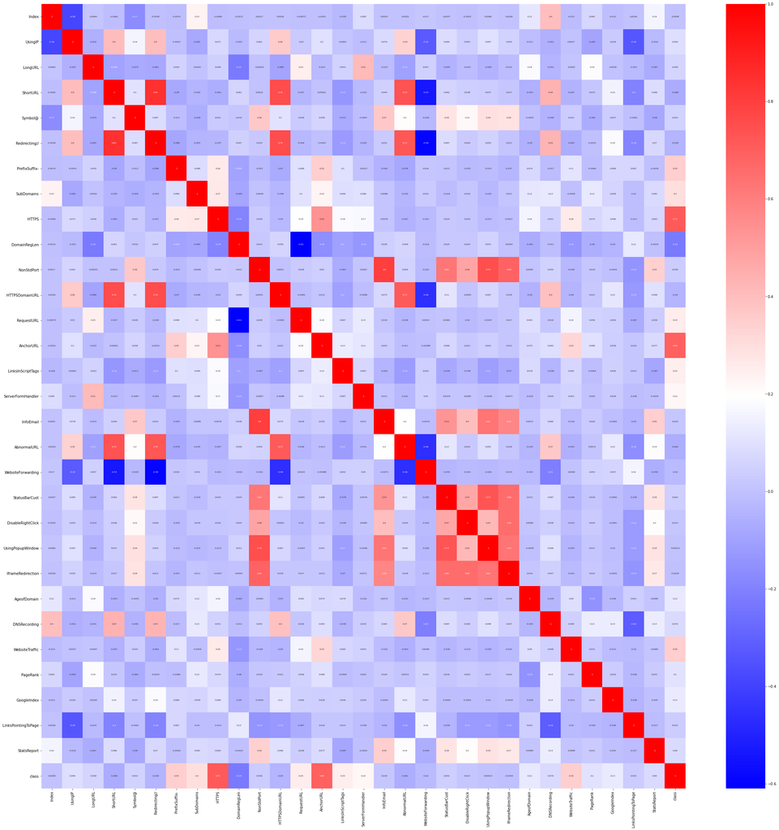

```python
import matplotlib.pyplot as plt
import seaborn as sns
fig, ax = plt.subplots(figsize=(40,40))
sns.heatmap(df.corr(),annot=True,cmap='bwr',linewidths=0,annot_kws={"fontsize":6})
plt.xticks(size=10)
plt.yticks(size=10)
plt.savefig("corr.png")
plt.show()
```

Remapeamos la clase que nos dice si el registro efectivamente es phishing o no. Por defecto, nos dice que si el registro, en la columna *class* marca 1, es phishing, si marca -1 es phishing. Para eso usamos una función que transforma el -1 a 0 y el -1 lo deje a 0. Usaremos la función definida como:

$$ f(x) = \dfrac{x+1}{2} $$$$ f(1) = \dfrac{1+1}{2} = 1 $$$$ f(-1) = \dfrac{-1+1}{2}= 0 $$

Esta función se la aplicamos a la columna class.

```python
df["class"]= df["class"].map(lambda x: int((x+1)/2))
```

```python
df
```

|  | Index | UsingIP | LongURL | ShortURL | Symbol@ | Redirecting// | PrefixSuffix- | SubDomains | HTTPS | DomainRegLen | ... | UsingPopupWindow | IframeRedirection | AgeofDomain | DNSRecording | WebsiteTraffic | PageRank | GoogleIndex | LinksPointingToPage | StatsReport | class |
| --- | --- | --- | --- | --- | --- | --- | --- | --- | --- | --- | --- | --- | --- | --- | --- | --- | --- | --- | --- | --- | --- |
| 0 | 0 | 1 | 1 | 1 | 1 | 1 | -1 | 0 | 1 | -1 | ... | 1 | 1 | -1 | -1 | 0 | -1 | 1 | 1 | 1 | 0 |
| 1 | 1 | 1 | 0 | 1 | 1 | 1 | -1 | -1 | -1 | -1 | ... | 1 | 1 | 1 | -1 | 1 | -1 | 1 | 0 | -1 | 0 |
| 2 | 2 | 1 | 0 | 1 | 1 | 1 | -1 | -1 | -1 | 1 | ... | 1 | 1 | -1 | -1 | 1 | -1 | 1 | -1 | 1 | 0 |
| 3 | 3 | 1 | 0 | -1 | 1 | 1 | -1 | 1 | 1 | -1 | ... | -1 | 1 | -1 | -1 | 0 | -1 | 1 | 1 | 1 | 1 |
| 4 | 4 | -1 | 0 | -1 | 1 | -1 | -1 | 1 | 1 | -1 | ... | 1 | 1 | 1 | 1 | 1 | -1 | 1 | -1 | -1 | 1 |
| ... | ... | ... | ... | ... | ... | ... | ... | ... | ... | ... | ... | ... | ... | ... | ... | ... | ... | ... | ... | ... | ... |
| 11049 | 11049 | 1 | -1 | 1 | -1 | 1 | 1 | 1 | 1 | -1 | ... | -1 | -1 | 1 | 1 | -1 | -1 | 1 | 1 | 1 | 1 |
| 11050 | 11050 | -1 | 1 | 1 | -1 | -1 | -1 | 1 | -1 | -1 | ... | -1 | 1 | 1 | 1 | 1 | 1 | 1 | -1 | 1 | 0 |
| 11051 | 11051 | 1 | -1 | 1 | 1 | 1 | -1 | 1 | -1 | -1 | ... | 1 | 1 | 1 | 1 | 1 | -1 | 1 | 0 | 1 | 0 |
| 11052 | 11052 | -1 | -1 | 1 | 1 | 1 | -1 | -1 | -1 | 1 | ... | -1 | 1 | 1 | 1 | 1 | -1 | 1 | 1 | 1 | 0 |
| 11053 | 11053 | -1 | -1 | 1 | 1 | 1 | -1 | -1 | -1 | 1 | ... | 1 | 1 | -1 | 1 | -1 | -1 | -1 | 1 | -1 | 0 |

11054 rows × 31 columns

Empezamos con los algoritmos deep learning.

- Importamos la librería Numpy para manejar arreglo de datos.
- Importamos desde la librería sklearn, para dividir los datos de entrenamiento y prueba.

```python
import numpy as np
from sklearn.model_selection import train_test_split
```

Definimos la variable independiente como X_df y lo definimos como todas las columnas de la base de datos exceptuando por **class**. La variable dependiente sera Y_df que sera la columna **class**.

```python
X_df = df
X_df = X_df.drop(df.columns[-1], axis=1)
y_df = df[df.columns[-1]]
```

Dividimos los datos como training y test con un porcentaje del 25%

```python
x_tr, x_ts, y_tr, y_ts = train_test_split(X_df, y_df, test_size = 0.25, random_state = 42)
```

Establecemos los formatos de y_tr como array de numpy y establecemos su forma.

```python
y_tr = np.asarray(y_tr, dtype = np.int)
y_ts = np.asarray(y_ts, dtype = np.int)

y_tr = np.reshape(y_tr, [len(y_tr),1])
y_ts = np.reshape(y_ts, [len(y_ts),1])

print(x_ts.shape)
print(x_tr.shape)
print(y_ts.shape)
print(y_tr.shape)
```

```
(2764, 30)
(8290, 30)
(2764, 1)
(8290, 1)
```

Importamos *MinMAxScaler* que nos permitirá normalizar los datos de entrada.

```python
from sklearn.preprocessing import MinMaxScaler, Normalizer
# Training Data
x_tr = MinMaxScaler().fit_transform(x_tr)
print("Training Data :", x_tr.shape)

# Testing Data
x_ts = MinMaxScaler().fit_transform(x_ts)
print("Testing Data :", x_ts.shape)
```

```
Training Data : (8290, 30)
Testing Data : (2764, 30)
```

Importamos todas las librerías necesarias para ejecutar el algoritmo que nos permitirá usar la red neuronal.

```python
import tensorflow as tf
from matplotlib import pyplot as plt
from keras.models import Sequential
from keras.layers.core import Dense
from keras.layers import Dropout
from tensorflow.keras.callbacks import EarlyStopping
from tensorflow.keras.callbacks import TensorBoard
from tensorflow.keras.callbacks import ReduceLROnPlateau
```

```python
# Hyperparameters
training_epochs = 200*5 # Total number of training epochs
learning_rate = 0.01 # The learning rate
momentum = 0.1
```

Creamos la arquitectura de nuestra red neuronal.

Esta configuración no fue aleatoria, después de muchas pruebas exhaustivas (1era capa con softmax, segunda capa con 16 entradas, solo dos capas, etc) concluimos que está saca el máximo rendimiento de la red.

```python
# create a model
def create_model():
    model = tf.keras.Sequential()
    # Hidden layer
    model.add(tf.keras.layers.Dense(len(X_df.columns), input_dim=len(X_df.columns),activation='tanh'))
    model.add(tf.keras.layers.Dense(8, input_dim=8,activation='sigmoid'))
    model.add(Dropout(0.5))
    # Output layer
    model.add(tf.keras.layers.Dense(1, activation='sigmoid'))

    # Compile a model
    model.compile(loss='binary_crossentropy',
                  optimizer=tf.keras.optimizers.SGD(learning_rate, momentum),
                  metrics=['accuracy'])
    return model
```

Creamos el clase model y lo ejecutamos

```python
model = create_model()
model.summary()
```

```
Model: "sequential"
_________________________________________________________________
Layer (type)                 Output Shape              Param #
=================================================================
dense (Dense)                (None, 30)                930
_________________________________________________________________
dense_1 (Dense)              (None, 8)                 248
_________________________________________________________________
dropout (Dropout)            (None, 8)                 0
_________________________________________________________________
dense_2 (Dense)              (None, 1)                 9
=================================================================
Total params: 1,187
Trainable params: 1,187
Non-trainable params: 0
_________________________________________________________________
```

Configuramos los callbacks de nuestra red neuronal.

- EarlyStopping nos permite detener las iteraciones de las redes cuando ya no mejore.
- TensorBoard nos permite monitorear las iteraciones y visusalizar de mejor manera la red.
- ReduceLROnPlateau reduce el learning rate cuando deje de mejorar la red.

```python
my_callbacks = [
    EarlyStopping(monitor='loss',patience=10),
    TensorBoard(log_dir="./",
                write_graph=True,update_freq="epoch"),
    ReduceLROnPlateau(monitor='loss', factor=0.2,
                              patience=50, min_lr=0.001)
]
```

Aquí ejecutamos la red neuronal. Los datos a entrenar sera x_tr, y_tr. Los datos de validación seran x_ts, y_ts.

```python
results = model.fit(
    x_tr, y_tr,
    epochs= training_epochs,
    batch_size=32,
    validation_data = (x_ts, y_ts),
    callbacks=my_callbacks,
    verbose = 1
)
```

Imprimimos los resultados acerca del training set y del testing set.

```python
print("Evaluating on training set...")
(loss, accuracy) = model.evaluate(x_tr, y_tr, verbose=0)
print("loss={:.4f}, accuracy: {:.4f}%".format(loss,accuracy * 100))

print("Evaluating on testing set...")
(loss, accuracy) = model.evaluate(x_ts, y_ts, verbose=0)
print("loss={:.4f}, accuracy: {:.4f}%".format(loss,accuracy * 100))
```

```
Evaluating on training set...
loss=0.1799, accuracy: 92.6779%
Evaluating on testing set...
loss=0.1897, accuracy: 92.4747%
```

Gráficamos la precisión y loss en contra de las iteraciones de la red.

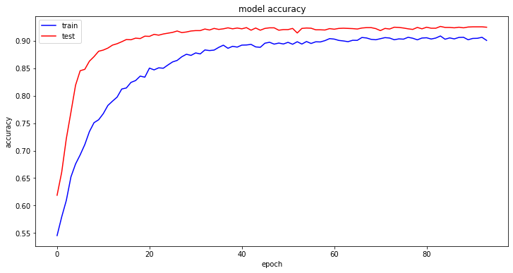

```python
# summarize history for accuracy
fig = plt.subplots(figsize=(12,6))
plt.plot(results.history['accuracy'],color="b")
plt.plot(results.history['val_accuracy'],color="r")
plt.title('model accuracy')
plt.ylabel('accuracy')
plt.xlabel('epoch')
plt.legend(['train', 'test'])
plt.show()
```

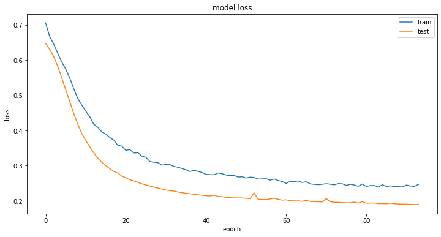

```python
# summarize history for loss
fig = plt.subplots(figsize=(12,6))

plt.plot(results.history['loss'])
plt.plot(results.history['val_loss'])
plt.title('model loss')
plt.ylabel('loss')
plt.xlabel('epoch')
plt.legend(['train', 'test'])
plt.show()


max_loss = np.max(results.history['loss'])
min_loss = np.min(results.history['loss'])
```

```python
print("Maximum Loss : {:.4f}".format(max_loss))
print("")
print("Minimum Loss : {:.4f}".format(min_loss))
print("")
print("Loss difference : {:.4f}".format((max_loss - min_loss)))
```

```
Maximum Loss : 0.7054

Minimum Loss : 0.2392

Loss difference : 0.4662
```